# Joint Headline HICP — 4-component Bayesian VAR with SV, outliers and monthly seasonal dummies

### 14.1 Which equation carries the persistent seasonal dynamics?

The previous session suggested that NEIG was the main source of the near-seasonal roots. The following diagnostic repeats that localization **draw by draw**.

For each equation (i), it sets that equation's lag coefficients at (L^2,\ldots,L^{12}) to zero while leaving:

- its first lag (L^1),
- every other equation,
- the constant,
- and all 11 seasonal dummies

unchanged. It then recomputes the companion spectral radius. A large fall in the radius when one equation is neutralized indicates that its higher-order lag polynomial is carrying the persistent cycle. This is a localization diagnostic only; it does not define a candidate production model.

```python
def _radius_after_equation_high_lag_neutralization(
    result: Mapping,
    *,
    n_draws: int,
) -> pd.DataFrame:
    B = _B_draws_as_k_by_n(result)
    total = B.shape[0]
    keep = min(int(n_draws), total)
    draw_idx = np.linspace(0, total - 1, keep, dtype=int)

    variables = list(result["variables"])
    n = len(variables)
    p = int(result["p"])
    k = B.shape[1]
    n_det = k - n * p

    rows = []
    for original_idx in draw_idx:
        B0 = B[original_idx]
        base_radius = float(
            np.max(np.abs(np.linalg.eigvals(_companion_from_Bkn(B0, n=n, p=p))))
        )
        row = {"draw_index": int(original_idx), "full_system": base_radius}

        for equation_j, equation_name in enumerate(variables):
            modified = B0.copy()
            for lag in range(1, p):
                start = n_det + lag * n
                modified[start : start + n, equation_j] = 0.0
            radius = float(
                np.max(np.abs(np.linalg.eigvals(_companion_from_Bkn(modified, n=n, p=p))))
            )
            row[f"neutralize_{equation_name}_L2_L{p}"] = radius
        rows.append(row)

    return pd.DataFrame(rows).set_index("draw_index")


root_source_by_draw = _radius_after_equation_high_lag_neutralization(
    result_12,
    n_draws=SEASONAL_SOURCE_LOCALIZATION_DRAWS,
)

root_source_summary = pd.DataFrame(
    {
        "q05_radius": root_source_by_draw.quantile(0.05),
        "median_radius": root_source_by_draw.median(),
        "q95_radius": root_source_by_draw.quantile(0.95),
    }
)
root_source_summary["median_drop_vs_full"] = (
    root_source_summary.loc["full_system", "median_radius"]
    - root_source_summary["median_radius"]
)

display(
    style_numeric_table(
        root_source_summary,
        caption="Posterior root-source localization: neutralize L2..Lp one equation at a time",
    )
)
```

Posterior root-source localization: neutralize L2..Lp one equation at a time

|  | q05_radius | median_radius | q95_radius | median_drop_vs_full |
| --- | --- | --- | --- | --- |
| full_system | 0.79 | 0.82 | 0.86 | 0.00 |
| neutralize_state__hicp_energy_L2_L12 | 0.76 | 0.78 | 0.81 | 0.03 |
| neutralize_state__hicp_food_L2_L12 | 0.79 | 0.82 | 0.85 | 1.22 × 10⁻⁴ |
| neutralize_state__hicp_neig_L2_L12 | 0.75 | 0.79 | 0.83 | 0.03 |
| neutralize_state__hicp_services_L2_L12 | 0.77 | 0.80 | 0.85 | 0.01 |

## 15. Formal seasonal tests on the log-level series — HEGY + Canova-Hansen

These tests answer a different question from the companion-root analysis and are therefore kept separate.

### HEGY

HEGY tests the null of a **unit root at a particular frequency**. For the monthly series, the relevant seasonal frequencies include the pairs corresponding to 12, 6, 4, 3 and approximately 2.4 months, plus the (\pi) root at 2 months.

The test is deliberately run on the **log-level HICP component**, not on (\Delta\log P_t). Testing after differencing would partly impose the conclusion we are trying to assess.

### Canova-Hansen

Canova-Hansen reverses the logic: its null is that the seasonal pattern is **stable**. Rejection therefore points toward changing seasonal amplitude/timing, which is exactly the limitation of fixed monthly dummies.

### Execution contract

The canonical model remains pure Python. Formal HEGY p-values are not reimplemented here with homemade critical values. If `Rscript` and the established R package `uroot` are available, the notebook calls them and imports the resulting statistics. If not, the cell continues without failure. As a Python fallback, if `pmdarima` is installed, the Canova-Hansen seasonal-differencing recommendation is also reported.

No result in this section automatically applies ((1-L^{12})).

```python
def _longest_complete_monthly_block(series: pd.Series) -> pd.Series:
    '''Longest contiguous non-missing monthly block; preserves the calendar phase.'''
    s = series.copy().astype(float)
    idx = pd.DatetimeIndex(s.index).to_period("M").to_timestamp(how="start")
    s.index = idx
    s = s.sort_index()

    valid = s.dropna()
    if valid.empty:
        raise ValueError(f"{series.name}: no non-missing observations.")

    ordinals = valid.index.to_period("M").asi8
    split_at = np.where(np.diff(ordinals) != 1)[0] + 1
    groups = np.split(np.arange(len(valid)), split_at)
    best = max(groups, key=len)
    block = valid.iloc[best]

    if len(block) < 5 * 12:
        raise ValueError(
            f"{series.name}: only {len(block)} contiguous monthly observations; "
            "too short for the formal seasonal diagnostics used here."
        )
    return block


formal_test_rows = []

if RUN_FORMAL_SEASONAL_TESTS:
    # ---------- Python Canova-Hansen fallback ----------
    try:
        from pmdarima.arima import nsdiffs as _pmdarima_nsdiffs
    except Exception as exc:
        _pmdarima_nsdiffs = None
        print("pmdarima Canova-Hansen fallback unavailable:", repr(exc))

    if _pmdarima_nsdiffs is not None:
        for name in state_levels.columns:
            block = _longest_complete_monthly_block(state_levels[name])
            try:
                recommended_D = int(
                    _pmdarima_nsdiffs(
                        block.to_numpy(dtype=float),
                        m=12,
                        max_D=1,
                        test="ch",
                    )
                )
                formal_test_rows.append(
                    {
                        "variable": name,
                        "family": "Canova-Hansen (pmdarima decision rule)",
                        "statistic_name": "recommended seasonal difference D",
                        "statistic": float(recommended_D),
                        "p_value": np.nan,
                        "null": "stable seasonal pattern",
                        "sample_start": block.index[0],
                        "sample_end": block.index[-1],
                        "n_obs": len(block),
                    }
                )
            except Exception as exc:
                print(f"{name}: pmdarima CH failed:", repr(exc))

    # ---------- Formal HEGY + CH via R package uroot ----------
    rscript = shutil.which("Rscript")
    if rscript is None:
        print(
            "Rscript not found: formal HEGY p-values and full uroot Canova-Hansen output "
            "are skipped. Posterior-root diagnostics above remain fully available."
        )
    else:
        probe = subprocess.run(
            [
                rscript,
                "-e",
                'quit(status=ifelse(requireNamespace("uroot", quietly=TRUE), 0, 42))',
            ],
            capture_output=True,
            text=True,
        )
        if probe.returncode != 0:
            print(
                "R package 'uroot' is not installed. Formal HEGY/CH skipped. "
                "Install it in R with install.packages('uroot') if you want this block."
            )
        else:
            with tempfile.TemporaryDirectory(prefix="headline_seasonal_tests_") as tmpdir:
                tmpdir = Path(tmpdir)

                for name in state_levels.columns:
                    block = _longest_complete_monthly_block(state_levels[name])
                    input_csv = tmpdir / "input.csv"
                    output_csv = tmpdir / "output.csv"
                    pd.DataFrame({"value": block.to_numpy(dtype=float)}).to_csv(
                        input_csv, index=False
                    )

                    start_year = int(block.index[0].year)
                    start_month = int(block.index[0].month)
                    maxlag = min(int(HEGY_MAX_LAG), max(0, len(block) // 10))

                    in_r = input_csv.as_posix().replace('"', '\\"')
                    out_r = output_csv.as_posix().replace('"', '\\"')

                    r_code = f'''
suppressPackageStartupMessages(library(uroot))
d <- read.csv("{in_r}")
x <- ts(as.numeric(d$value), start=c({start_year}, {start_month}), frequency=12)

h <- hegy.test(
  x,
  deterministic=c(1,0,1),
  lag.method="BIC",
  maxlag={maxlag},
  pvalue="RS"
)

ch <- ch.test(
  x,
  type="trigonometric",
  lag1=TRUE,
  sid="all",
  pvalue="RS"
)

pack_result <- function(obj, family, null_text) {{
  st <- as.numeric(obj$statistics)
  pv <- as.numeric(obj$pvalues)
  nm <- names(obj$statistics)
  if (is.null(nm)) nm <- paste0(family, "_", seq_along(st))
  data.frame(
    family=rep(family, length(st)),
    statistic_name=nm,
    statistic=st,
    p_value=pv,
    null=rep(null_text, length(st)),
    stringsAsFactors=FALSE
  )
}}

out <- rbind(
  pack_result(h, "HEGY (uroot)", "unit root at tested frequency"),
  pack_result(ch, "Canova-Hansen trigonometric (uroot)", "stable seasonal pattern")
)
write.csv(out, "{out_r}", row.names=FALSE)
'''
                    run = subprocess.run(
                        [rscript, "-e", r_code],
                        capture_output=True,
                        text=True,
                    )
                    if run.returncode != 0:
                        print(f"{name}: uroot seasonal tests failed.")
                        print(run.stderr[-2000:])
                        continue

                    imported = pd.read_csv(output_csv)
                    imported.insert(0, "variable", name)
                    imported["sample_start"] = block.index[0]
                    imported["sample_end"] = block.index[-1]
                    imported["n_obs"] = len(block)
                    formal_test_rows.extend(imported.to_dict("records"))
else:
    print("RUN_FORMAL_SEASONAL_TESTS=False — formal seasonal tests skipped.")

formal_seasonal_tests = pd.DataFrame(formal_test_rows)

if formal_seasonal_tests.empty:
    print("No external formal seasonal-test result was produced.")
else:
    display(
        style_numeric_table(
            formal_seasonal_tests.set_index(["variable", "family", "statistic_name"]),
            caption="Formal seasonal diagnostics on log-level HICP component series",
        )
    )
```

```
pmdarima Canova-Hansen fallback unavailable: ModuleNotFoundError("No module named 'pmdarima'")
Rscript not found: formal HEGY p-values and full uroot Canova-Hansen output are skipped. Posterior-root diagnostics above remain fully available.
No external formal seasonal-test result was produced.
```

### 15.1 Decision rule for the current model

The evidence should be read jointly rather than from one statistic.

For a component where:

1. Canova-Hansen does **not** reject seasonal stability,
2. HEGY rejects seasonal unit roots at the problematic frequencies, and
3. the posterior probability of a near-unit root in those frequency bands is small,

fixed monthly dummies are adequate.

Conversely, evidence that is more consistent with **time-varying seasonality** is:

[ \text{CH rejects stability} \quad+\quad \text{HEGY does not reject a seasonal unit root} \quad+\quad P(|\lambda|>0.95\mid\text{seasonal frequency, data})\text{ is high}. ]

If that pattern is concentrated in NEIG while Services looks stable, the next extension should be **component-specific**: retain the 11 fixed monthly dummies for the common deterministic seasonal component, and add a stochastic seasonal state to NEIG only.

This notebook deliberately stops at the diagnostic stage. In particular:

- it does not apply ((1-L^{12}));
- it does not alter `result_12`;
- it does not promote a stochastic-seasonality specification;
- it does not change the dashboard/registry contract.

A model change should occur only after the diagnostics above are inspected on the executed vintage.

## 16. Posterior predictive checks

Posterior predictive checks

|  | observed | replicated_median | replicated_q05 | replicated_q95 |
| --- | --- | --- | --- | --- |
| state__hicp_energy: mean | 2.90 × 10⁻³ | 2.52 × 10⁻³ | -9.65 × 10⁻⁴ | 5.93 × 10⁻³ |
| state__hicp_energy: sd | 0.02 | 0.02 | 0.02 | 0.04 |
| state__hicp_energy: maximum_absolute | 0.11 | 0.12 | 0.06 | 0.46 |
| state__hicp_food: mean | 2.12 × 10⁻³ | 1.57 × 10⁻³ | -1.16 × 10⁻⁴ | 3.04 × 10⁻³ |
| state__hicp_food: sd | 3.83 × 10⁻³ | 3.92 × 10⁻³ | 3.15 × 10⁻³ | 6.77 × 10⁻³ |
| state__hicp_food: maximum_absolute | 0.02 | 0.02 | 0.01 | 0.07 |
| state__hicp_neig: mean | 8.06 × 10⁻⁴ | 5.23 × 10⁻⁴ | 3.81 × 10⁻⁵ | 1.00 × 10⁻³ |
| state__hicp_neig: sd | 0.02 | 0.02 | 0.01 | 0.02 |
| state__hicp_neig: maximum_absolute | 0.04 | 0.04 | 0.03 | 0.08 |
| state__hicp_services: mean | 1.85 × 10⁻³ | 1.76 × 10⁻³ | 1.23 × 10⁻³ | 2.26 × 10⁻³ |
| state__hicp_services: sd | 5.42 × 10⁻³ | 5.07 × 10⁻³ | 4.67 × 10⁻³ | 6.04 × 10⁻³ |
| state__hicp_services: maximum_absolute | 0.01 | 0.02 | 0.01 | 0.05 |

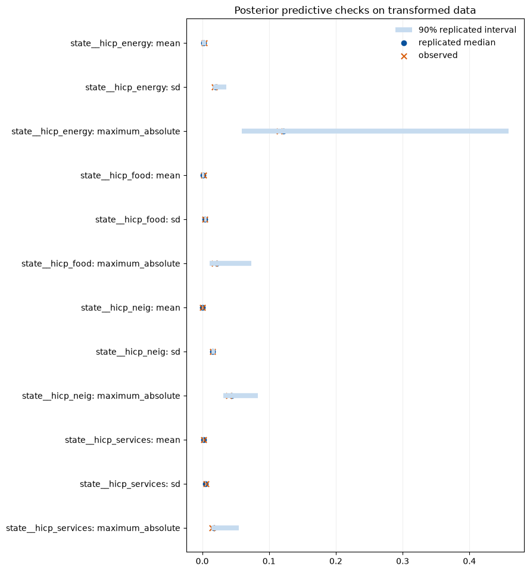

```python
ppc_summary, ppc_draws = posterior_predictive_statistics(
    result_12,
    n_draws=min(300, result_12["n_draws"]),
    seed=321,
)

display(style_numeric_table(ppc_summary, caption="Posterior predictive checks"))

fig = plot_posterior_predictive_check(ppc_summary)
display(fig)
plt.close(fig)
```